# Catálogo de Servidores

## Catálogo de Servidores Gerenciar Dbs de servidor

Um administrador de bancos de dados pode desejar gerenciar bancos de dados criados ou não pelo DsgTools. A figura 5 mostra o estado inicial da ferramenta.

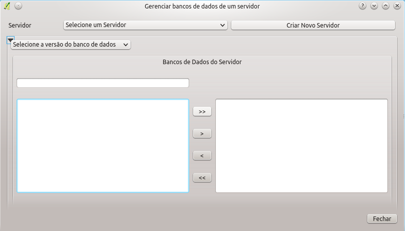

*Figura 5: Gerenciar Dbs de Servidor - Estado inicial*

O primeiro passo para iniciar o gerenciamento é selecionar um servidor. Após isso deve-se selecionar os bancos que serão gerenciados, múltiplos bancos podem ser selecionados (Para facilitar este manual, apenas um banco será usado).

Após selecionar um servidor deve ser selecionado uma versão de banco de dados. O DSTools permite trabalhar com bancos ET-EDGV 2.1.3, ET-EDGV Fter 2ª Edição e bancos não ET-EDGV. A partir da versão 3.0 o DSGTools permite acesso a qualquer banco PostGIS, tornando o DSGTools uma ferramenta genérica no que diz respeito a bancos PostGIS. A figura mostra o caso da seleção de bancos EDGV 2.1.3.

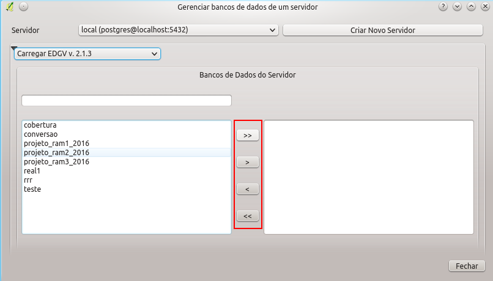

*Figura 6: Seleção de bancos EDGV 2.1.3*

Os botões em destaque no meio do diálogo acima permitem respectivamente, gerenciar tudo, gerenciar somente os bancos selecionados, remover somente os selecionados da gestão, remover todos os bancos da gestão.

Após a seleção é possível acessar abas com funcionalidades específicas, cada uma delas será abordada nos itens a seguir.

### Administração do Banco de Dados

A figura 7 mostra o que se obtem ao se entrar nesta aba.

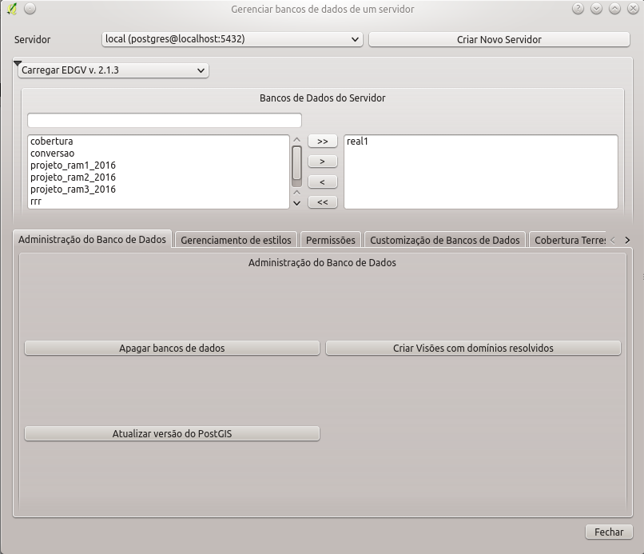

*Figura 7: Administração de banco de dados*

Nela é possível:

- Apagar os bancos selecionados
- Atualizar versão do PostGIS: Esta ferramenta permite que bancos criados com versões antigas do PostGIS (menores que a versão atualmente instalada) sejam atualizados de maneira automática.
- Criar Visões com domínios resolvidos: Permite que sejam criadas visões das tabelas dos bancos selecionados com os domínios resolvidos, ou seja, ao invés de se ver os números dos code lists da EDGV é possível ver diretamente o texto dos domínios.

### Gerenciamento de estilos

A figura 8 mostra o que se obtem ao se clicar nesta aba.

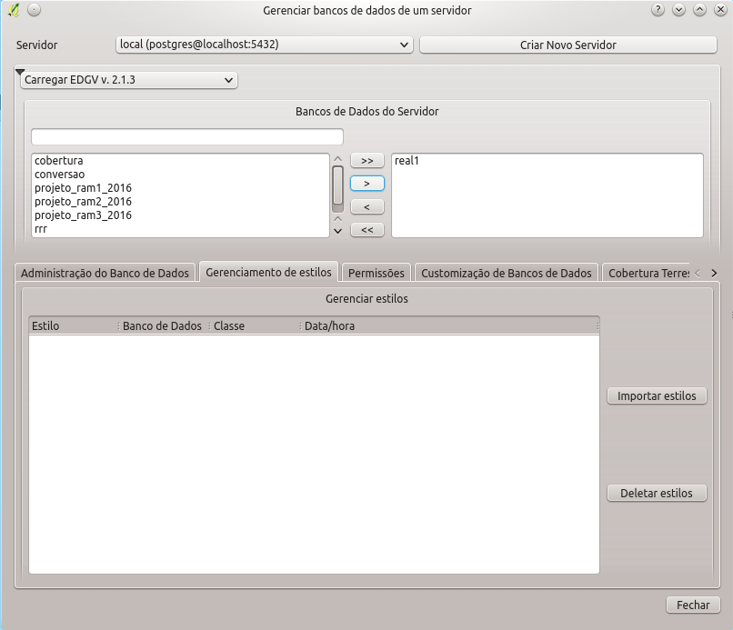

*Figura 8: Gerenciamento de estilos*

Nesta aba é possível Importar estilos para o banco selecionado e Deletar estilos do banco selecionado.

### Permissões

O sistema de gerenciamento de permissões do DSGTools evoluiu na versão 3.0, ficando mais amigável ao usuário. Vejamos as diferenças implementadas. A figura 9 mostra a situação inicial da aba de permissões.

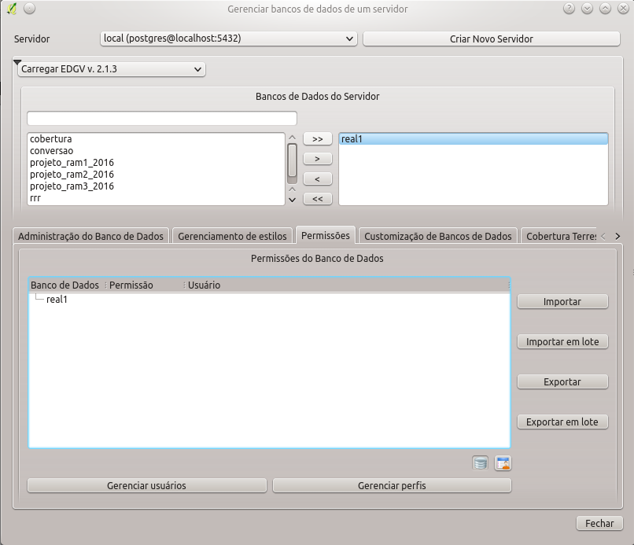

*Figura 9: Gerenciamento de permissões*

Nos itens seguintes serão abordadas cada uma das ferramentas desta aba.

#### Gerenciar usuários

No botão gerenciar usuários é possível criar, remover e mudar senha de usuários no PostgreSQL. Ao se clicar no botão se obtém o diálogo mostrado na figura 10.

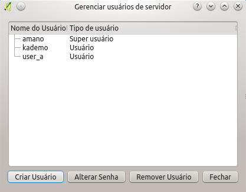

*Figura 10: Gerenciando usuários*

Ao se clicar em Criar Usuário se obtém o seguinte:

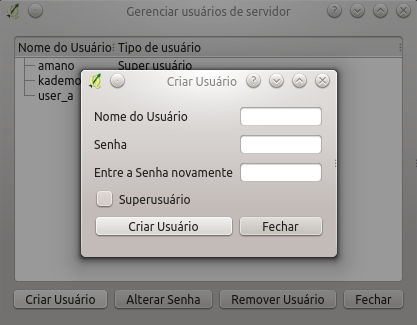

A criação de usuários é direta e simples, basta entrar com os dados solicitados e clicar em Criar Usuário.

Ao se clicar em Alterar Senha se obtém o seguinte:

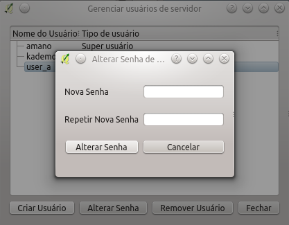

*Figura 11: Alterarando Senha de Usuários*

Basta entrar com a senha nova e repetir a mesma para garantir que os dados foram entrados corretamente e clicar em Alterar Senha.

Finalizando, para se remover usuários basta selecionar pelo menos um e clicar em Remover Usuário.

#### Gerenciar Perfis

Ao se clicar em Gerenciar Perfis se obtém o seguinte:

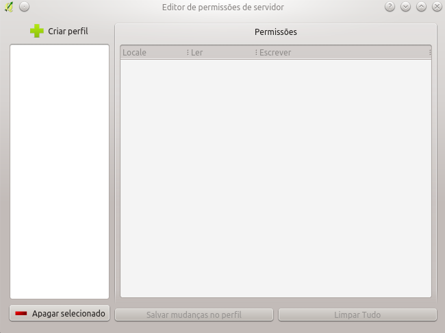

*Figura 12: Editando permissões*

Neste diálogo é possível criar e apagar modelos de permissões e salvar mudanças ou reverter tudo ao estado original. Para se criar um perfil deve-se clicar em Criar Perfil e posteriormente deve-se selecionar o banco que será usado como base para a criação do modelo de permissões. Preencha o campo Nome da Propriedade com o nome desejado para o modelo de permissões. No exemplo abaixo é mostrado a criação de um modelo de permissões para hidrografia.

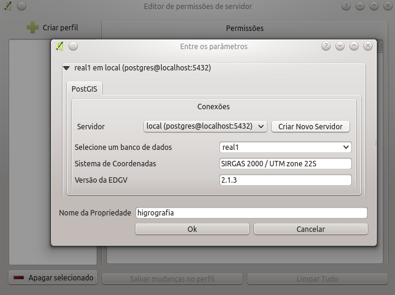

*Figura 13: Modelo de permissão para hidrografia*

Ao se confirmar a escolha é possível ver a seguinte figura onde é possível definir que partes do banco terão permissões de leitura e/ou escrita. No caso em questão se deseja que seja possível ler tudo e somente escrever na categoria hidrografia. A figura 14 mostra o resultado esperado.

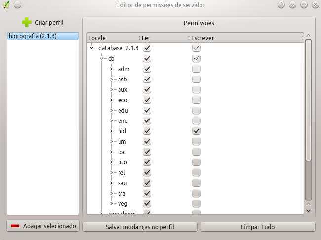

*Figura 14: Permissões de leitura total e escrita em hidrografia*

Após terminar de editar o modelo basta clicar em Salvar mudanças no perfil para terminar a edição. Agora a permissão está disponível para ser aplicada aos usuários do banco, isso pode ser visto na figura 15.

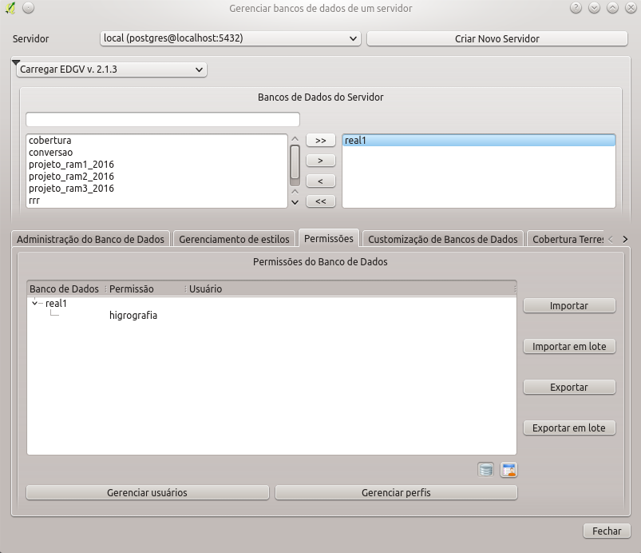

*Figura 15: Modelo de permissão disponível*

Para seguir, resta aplicar o modelo de permissões criado a algum usuário, para tanto deve se clicar com o botão direito do *mouse* no modelo criado para ter acesso ao seguinte menu.

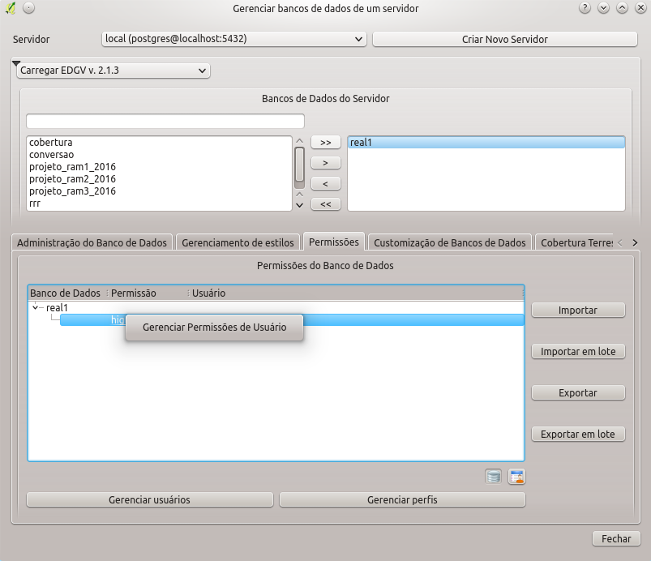

*Figura 16: Gerenciando permissões de usuário*

Ao se clicar no menu mostrado se obtém o seguinte:

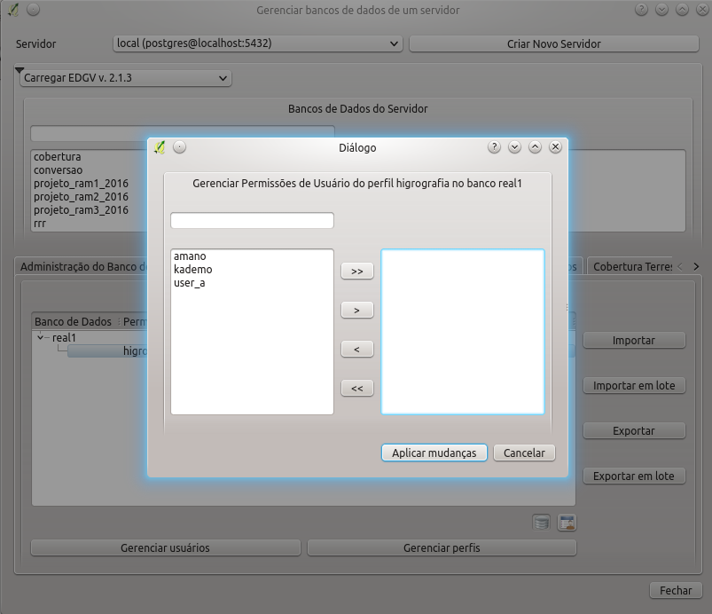

*Figura 17: Gerenciando permissões de usuário*

Os botões centrais funcionam conforme já mencionado anteriormente. Basta selecionar os usuários aos quais se deseja atribuir o modelo de permissão selecionado e clicar em Aplicar Mudanças para concluir, como se pode ver na figura abaixo. Neste diálogo é possível atribuir e desatribuir usuários de maneira unificada.

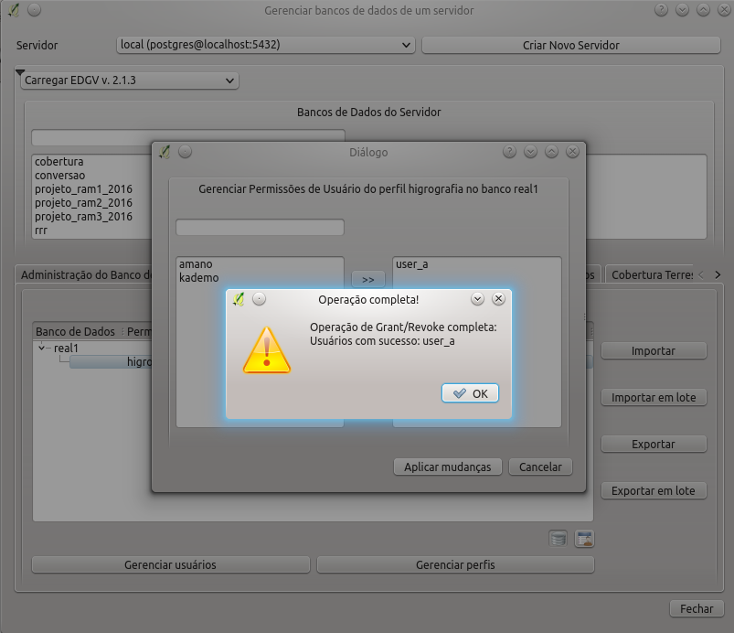

*Figura 18: Atribuindo permissões*

Agora é possível ver na figura 19 que o usuário user_a possui a permissão para ler todo o banco real1, porém só possui permissão para escrever nas classes da categoria de hidrografia.

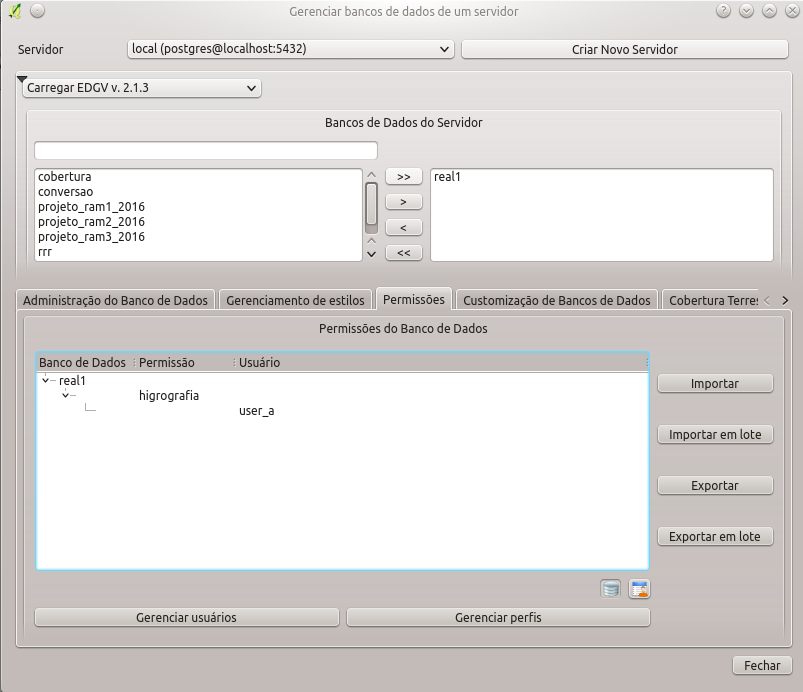

*Figura 19: Permissão atribuida*

Na janela da figura 17 é possível gerenciar permissões de usuários de maneira unificada, porém caso se deseje revogar permissões de um usuário específico é possível clicar com o botão direito nele e clicar Revogar usuário como se pode ver na figura abaixo.

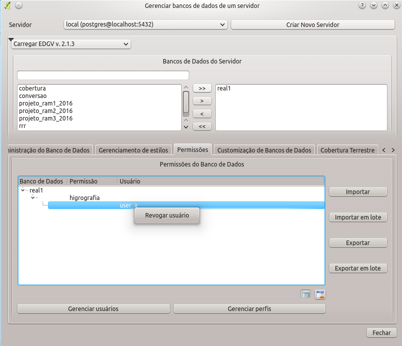

*Figura 20: Revogando usuário específico*

#### Importação/Exportação

Esta aba também permite que modelos de permissões sejam importados e exportados, essas opções são acessadas pelos botões presentes ao lado como se pode ver na figura abaixo.

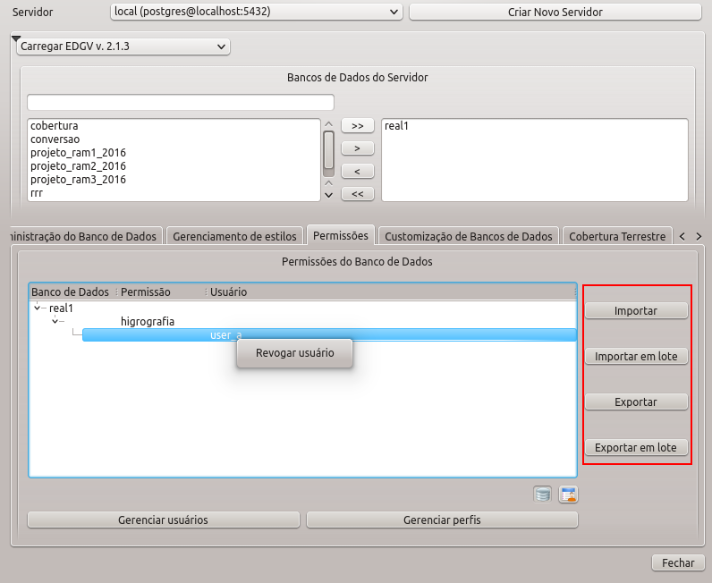

*Figura 21: Botões de importação/exportação*

### Cobertura Terrestre

Esta aba permite que sejam criados ajustes de cobertura terrestre que possibilitam a aquisição de feições por meio da abordagem de linha/centróide. A situação inicial desta aba pode ser vista na figura abaixo.

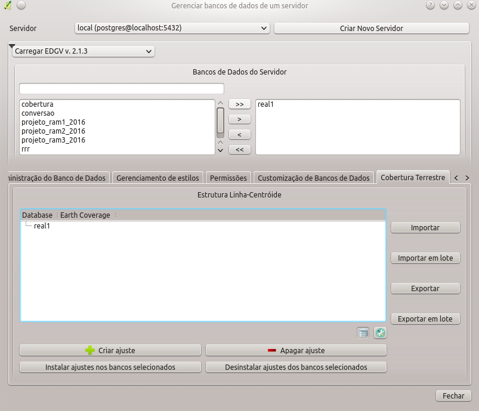

*Figura 22: Ajustes de cobertura terrestre*

#### Criar ajuste

Os ajustes de cobertura terrestre dependem da seleção de um banco de dados que será utilizado como base conforme visto na figura 13. Supondo que o nome do ajuste em questão tenha sido definido como linha_centroide, se obtém o seguinte:

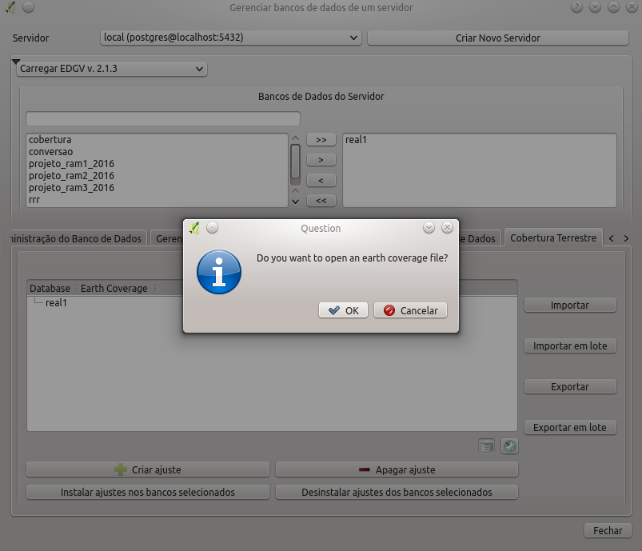

*Figura 23: Criando ajuste de cobertura terrestre*

Vamos supor que se deseja iniciar um ajuste do zero, para tanto se deve clicar em Cancelar, isso mostrará a seguinte janela:

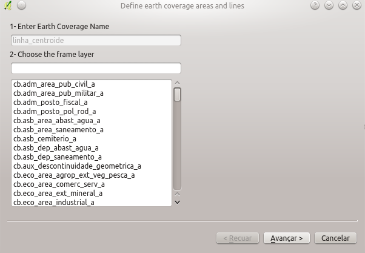

*Figura 24: Criando o ajuste*

Agora se inicia o ajuste propriamente dito, para tanto deve se escolher a classe de moldura. Ao se escrever o nome as camadas possíveis são filtradas. Para bancos EDGV basta escrever moldura, selecionar a classe public.aux_moldura_a e clicar em Avançar para ter acesso ao seguinte:

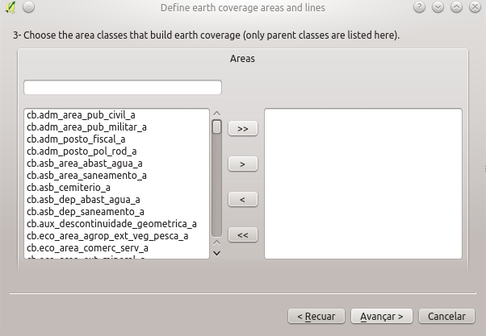

*Figura 25: Classes do tipo área que compõem a cobertura terrestre*

As classes que formam a cobertura terrestre devem ser selecionadas nesta janela com o uso dos botões presentes no meio da janela como já visto anteriormente.

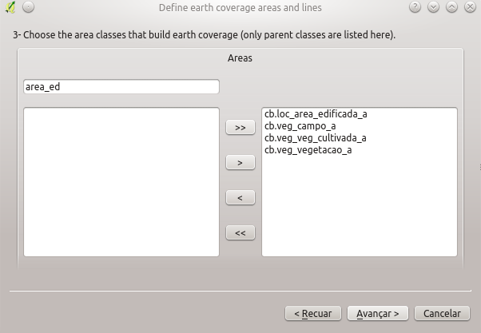

*Figura 26: Seleção de classes*

Clicando em Avançar passamos para o próximo passo como se pode ver abaixo.

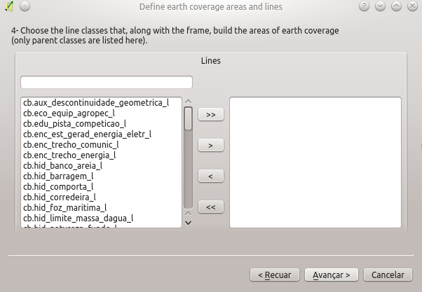

*Figura 27: Seleção de linhas de cobertura terrestre*

Da mesma forma, selecione as linhas que fecham a cobertura terrestre e clique em Avançar para ter acesso ao mostrado abaixo.

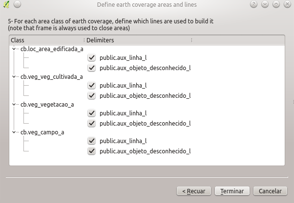

*Figura 28: Terminando o ajuste de cobertura terrestre*

Para finalizar selecione quais delimitadores de fato fecham as áreas da cobertura terrestre clicando nas caixa de seleção mostradas na figura 28. Para finalizar clique em Terminar para voltar.

#### Apagar ajuste

A opção de apagar ajuste permite apagar os ajustes já criados, basta selecionar os ajustes que se deseja apagar e clicar em OK.

#### Instalar ajustes nos bancos selecionados

Permite instalar os ajustes já criados nos bancos selecionados.

#### Desinstalar ajustes nos bancos selecionados

Permite desinstalar os ajustes já criados nos bancos selecionados.

É possível remover todas os ajustes de cobertura terrestre de um dado banco com por meio do menu que aparece ao se clicar com o botão direito no banco desejado, basta clicar em Uninstall all settings from selected database e confirmar a escolha. Isto pode ser visto na figura abaixo.

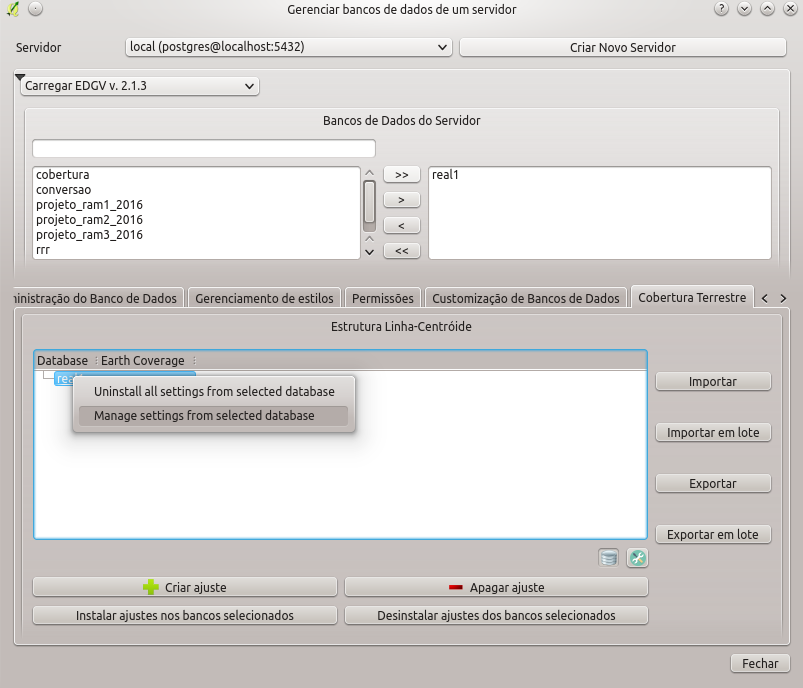

*Figura 29: Opções de cobertura terrestre para o banco selecionado*

Ao se clicar em Manage settings from selected database é possível fazer a escolha do que se deseja instalar ou desinstalar do banco selecionado.

#### Menu dos ajustes instalados

Para se acessar o menu dos ajustes de cobertura terrestre é necessário clicar com o botão direito no ajuste instalado. O menu pode ser visto na figura a seguir.

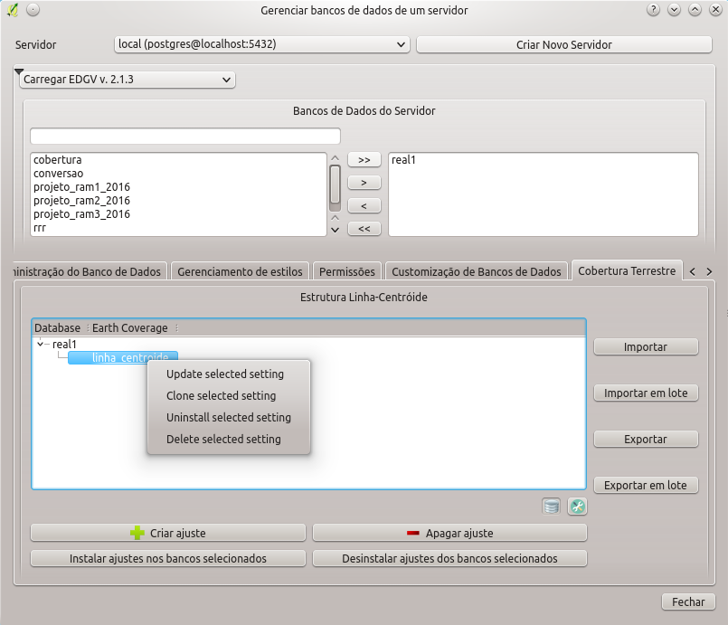

*Figura 30: Menu de contexto dos ajustes de cobertura instalados*

O menu contém as seguintes opções:

1. Update selected setting: Permite modificar o ajuste de cobertura terrestre;
2. Clone selected setting: Cria uma cópia do ajuste de cobertura terrestre. Funciona como uma criação, porém partindo de um ajuste já criado.
3. Uninstall selected setting: Desinstala o ajuste do banco em que está instalado; e
4. Delete selected setting: Faz o mesmo que a opção 3, porém remove o ajuste não sendo mais possível utilizá-lo.

#### Importação/Exportação

Funciona como já explicado em Importação/Exportação.

### Ajustes de Reclassificação

Esta aba permite que sejam criados ajustes de reclassificação de feições que permitem que feições de uma camada sejam reclassificadas (movidas) para outra camada de acordo com atributos já pré-estabelecidos pelo usuário. Estes ajsutes são muito úteis durante a etapa de reambulação, onde o operador pode, de maneira automatizada, reclassificar feições desconhecidas com apenas um clique de um botão. Para se criar um ajuste deve-se primeiramente clicar em Criar Ajuste e selecionar um banco para ser usado como base. Com o banco base selecionado se tem acesso ao diálogo mostrado abaixo.

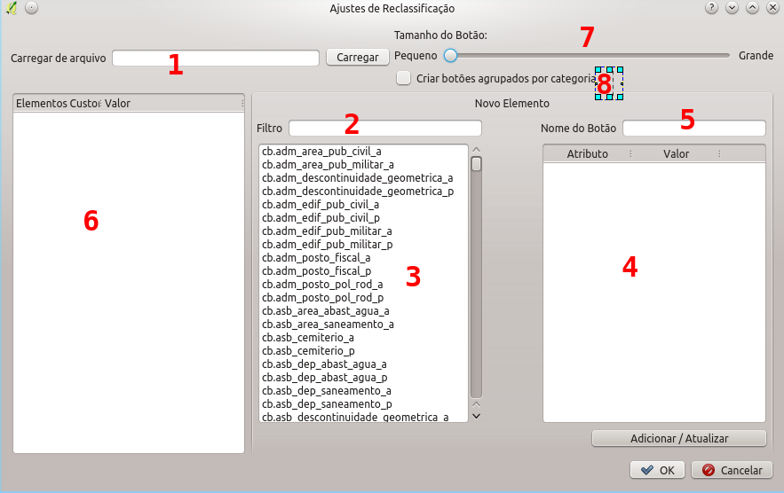

*Figura 31: Ajustes de reclassificação*

A janela de configuração é dividida em partes (figura 31), quais sejam:

1. **Carregar arquivo:** Carrega um arquivo de configuração de reclassificação já existente
2. **Filtro:** Utilização de um filtro para rápida localização de uma feição na EDGV
3. **Classes da EDGV:** Classes da EDGV selecionada
4. **Atributos da classe:** Onde o usuário ajusta e define os valores dos atributos usados na reclassificação. `Atributos marcados em vermelho são atributos obrigatórios`
5. **Nome do botão:** Nome do botão de reclassificação para os ajustes efetuados
6. **Configuração de reclassificação:** Estrutura de botões criada pelo usuário.
7. **Tamanho do botão:** Seleciona o tamanho do botão que aparecerá na próxima janela, visa identificar melhor cada botão.
8. **Criar botões agrupados por categoria:** Permite que o usuário crie os botões agrupados por categorias para melhorar a organização dos mesmos.

Para iniciar uma nova configuração o usuário deve inicialmente selecionar as classes que se quer definir na configuração de reclassificação, para tanto, podemos usar o `Filtro` e buscar, por exemplo, a classe trecho rodoviário para que possamos criar botões para reclassificar rodovias federais (botão com nome BR) e rodovias estaduais (botão com nome RJ). Na figura abaixo vemos o caso da criação do botão BR. Após definir os valores dos atributos, basta ao usuário clicar no botão `Adicionar/Atualizar` logo abaixo dos atributos para chegar ao resultado da figura 32.

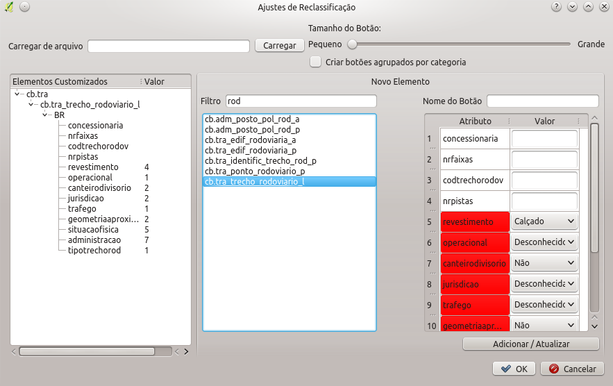

*Figura 32: Ajustes para rodovia federal*

Seguindo em frente, podemos fazer o mesmo para rodovias estaduais para o Estado do Rio de Janeiro.

Finalizando a criação da configuração de reclassificação basta ao usuário clicar em OK. Agora o ajuste de reclassificação está disponível e pode ser visto clicando-se no botão em destaque na figura abaixo.

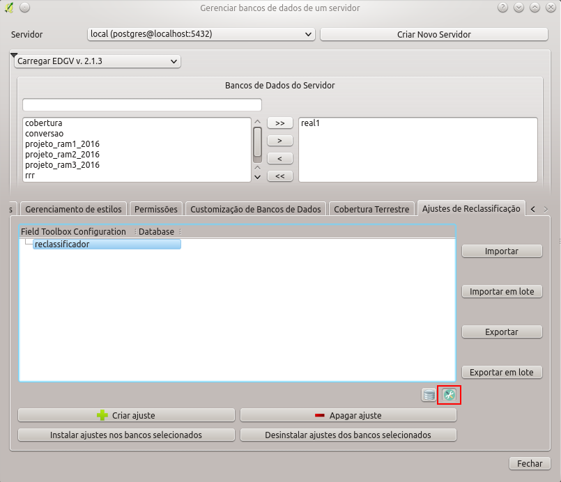

*Figura 33: Acessando o ajuste de reclassificação*

#### Apagar ajuste

A opção de apagar ajuste permite apagar os ajustes já criados, basta selecionar os ajustes que se deseja apagar e clicar em OK.

#### Instalar ajustes nos bancos selecionados

Permite instalar os ajustes já criados nos bancos selecionados.

#### Desinstalar ajustes nos bancos selecionados

Permite desinstalar os ajustes já criados nos bancos selecionados.

#### Manipulando ajustes de reclassificação nos bancos de maneira individual

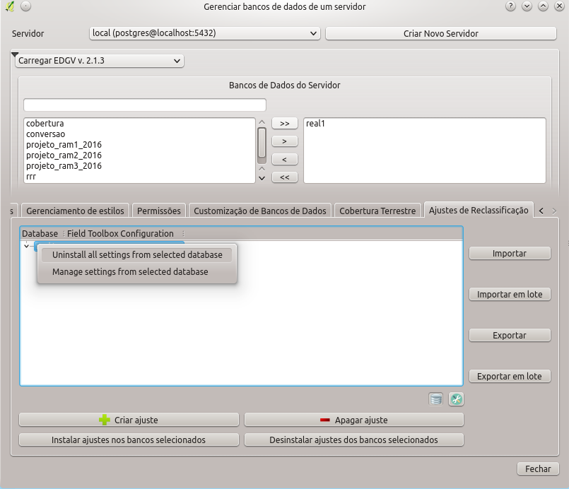

Ao se clicar em Manage settings from selected database é possível fazer a escolha do que se deseja instalar ou desinstalar do banco selecionado.

#### Menu dos ajustes instalados

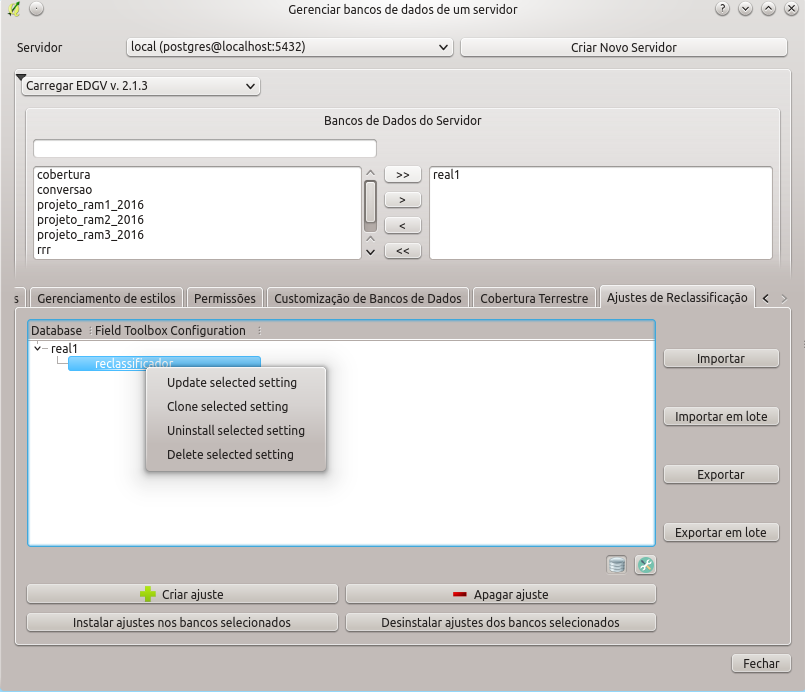

#### Importação/Exportação

Funciona como já explicado em Importação/Exportação.